# iTwiner regularizer

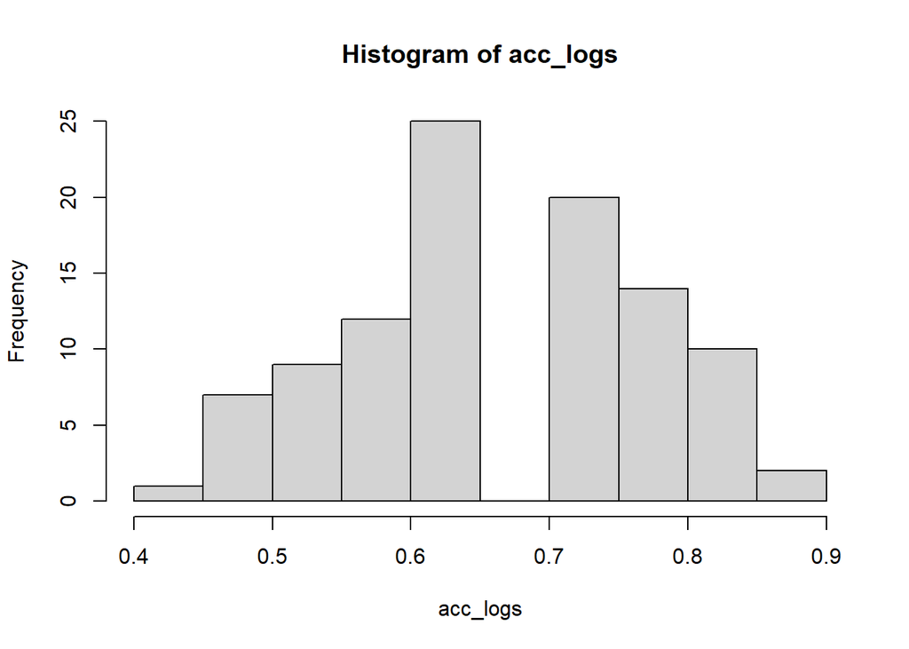

```r
acc_logs <- acc[4,]
hist(acc_logs)
```

```r
mean(acc_logs)
```

```
## [1] 0.6652941
```

```r
median(acc_logs)
```

```
## [1] 0.6470588
```

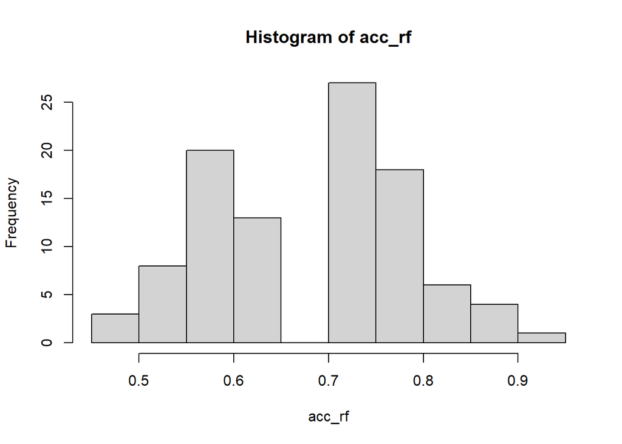

```r
acc_rf <- acc[5,]
hist(acc_rf)
```

```r
mean(acc_rf)
```

```
## [1] 0.6805882
```

```r
median(acc_rf)
```

```
## [1] 0.7058824
```

- Misclassification

```r
# miscl
miscl_trees <- miscl[1,]
#hist(miscl_trees)
mean(miscl_trees)
```

```
## [1] 6.8
```

```r
median(miscl_trees)
```

```
## [1] 7
```

```r
miscl_svm <- miscl[2,]
#hist(miscl_svm)
mean(miscl_svm)
```

```
## [1] 5.33
```

```r
median(miscl_svm)
```

```
## [1] 5
```

```r
miscl_svmR <- miscl[3,]
#hist(miscl_svmR)
mean(miscl_svmR)
```

```
## [1] 7.8
```

```r
median(miscl_svmR)
```

```
## [1] 8
```

```r
miscl_logs <- miscl[4,]
#hist(miscl_logs)
mean(miscl_logs)
```

```
## [1] 5.69
```

```r
median(miscl_logs)
```

```
## [1] 6
```

```r
miscl_rf <- miscl[5,]
#hist(miscl_rf)
mean(miscl_rf)
```

```
## [1] 5.43
```

```r
median(miscl_rf)
```

```
## [1] 5
```

- Sensitivity

```r
# sensitivity
sensitivity_trees <- sensitivity[1,]
sensitivity_trees <- na.omit(sensitivity_trees)
#hist(sensitivity_trees)
mean(sensitivity_trees)
```

```
## [1] 0.5825435
```

```r
median(sensitivity_trees)
```

```
## [1] 0.5714286
```

```r
sensitivity_svm <- sensitivity[2,]
sensitivity_svm <- na.omit(sensitivity_svm)
#hist(sensitivity_svm)
mean(sensitivity_svm)
```

```
## [1] 0.8234422
```

```r
median(sensitivity_svm)
```

```
## [1] 0.8
```

```r
sensitivity_svmR <- sensitivity[3,]
sensitivity_svmR <- na.omit(sensitivity_svmR)
#hist(sensitivity_svmR)
mean(sensitivity_svmR)
```

```
## [1] 0.5569607
```

```r
median(sensitivity_svmR)
```

```
## [1] 0.5
```

```r
sensitivity_logs <- sensitivity[4,]

sensitivity_logs <- na.omit(sensitivity_logs)
#hist(sensitivity_logs)
mean(sensitivity_logs)
```

```
## [1] 0.6849716
```

```r
median(sensitivity_logs)
```

```
## [1] 0.6666667
```

```r
sensitivity_rf <- sensitivity[5,]
sensitivity_rf <- na.omit(sensitivity_rf)
#hist(sensitivity_rf)
mean(sensitivity_rf)
```

```
## [1] 0.752263
```

```r
median(sensitivity_rf)
```

```
## [1] 0.7321429
```

- Specificity

```r
# specificity
specificity_trees <- specificity[1,]
specificity_trees <- na.omit(specificity_trees)
#hist(specificity_trees)
mean(specificity_trees)
```

```
## [1] 0.6292491
```

```r
median(specificity_trees)
```

```
## [1] 0.6201923
```

```r
specificity_svm <- specificity[2,]
specificity_svm <- na.omit(specificity_svm)
#hist(specificity_svm)
mean(specificity_svm)
```

```
## [1] 0.6698097
```

```r
median(specificity_svm)
```

```
## [1] 0.6547619
```

```r
specificity_svmR <- specificity[3,]
specificity_svmR <- na.omit(specificity_svmR)
#hist(specificity_svmR)
mean(specificity_svmR)
```

```
## [1] 0.5499586
```

```r
median(specificity_svmR)
```

```
## [1] 0.5333333
```

```r
specificity_logs <- specificity[4,]
specificity_logs <- na.omit(specificity_logs)
#hist(specificity_logs)
mean(specificity_logs)
```

```
## [1] 0.6813329
```

```r
median(specificity_logs)
```

```
## [1] 0.6666667
```

```r
specificity_rf <- specificity[5,]
specificity_rf <- na.omit(specificity_rf)
#hist(specificity_rf)
mean(specificity_rf)
```

```
## [1] 0.6679705
```

```r
median(specificity_rf)
```

```
## [1] 0.6666667
```

- False Neg

```r
# fneg
fneg_trees <- fneg[1,]
#hist(fneg_trees)
mean(fneg_trees)
```

```
## [1] 3.28
```

```r
median(fneg_trees)
```

```
## [1] 3
```

```r
fneg_svmL <- fneg[2,]
#hist(fneg_svmL)
mean(fneg_svmL)
```

```
## [1] 4.21
```

```r
median(fneg_svmL)
```

```
## [1] 4
```

```r
fneg_svmR <- fneg[3,]
#hist(fneg_svmR)
mean(fneg_svmR)
```

```
## [1] 5.91
```

```r
median(fneg_svmR)
```

```
## [1] 6
```

```r
fneg_logs <- fneg[4,]
#hist(fneg_logs)
mean(fneg_logs)
```

```
## [1] 3.11
```

```r
median(fneg_logs)
```

```
## [1] 3
```

```r
fneg_rf <- fneg[5,]
#hist(fneg_rf)
mean(fneg_rf)
```

```
## [1] 3.77
```

```r
median(fneg_rf)
```

```
## [1] 4
```

#### 3.3.4.2 2) Classification with regularization (EN and iTwiner)

```r
xdata <- xdataT


ydata.raw <- as.data.frame(clinic1$class)
ydata.raw$row <- DATASET1$ID
#
# # ydata.raw$class <- c(rep(0,28),rep(1,34))
#
ydata.raw$`clinic1$class`[ydata.raw$`clinic1$class` == "P"] <- 0
ydata.raw$`clinic1$class`[ydata.raw$`clinic1$class` == "Pm"] <- 1
rownames(ydata.raw) <- DATASET1$ID

xdata <- xdata[rownames(xdata) %in%
                         rownames(ydata.raw),]

ydata.raw <- as.data.frame(ydata.raw[rownames(ydata.raw) %in%
                         rownames(xdata),])

xdata <- xdata[ order(row.names(xdata)), ]

ydata.raw <- ydata.raw[ order(row.names(ydata.raw)), ]



ydata <- as.data.frame(ydata.raw)
ydata$`clinic1$class` <- as.numeric(ydata$`clinic1$class`)
```

```r
times_boot <- 1000

nvar_selected_1 <- matrix(0,2,times_boot)

var_selected_en1 <- vector("list")
var_selected_iTwiner1 <- vector("list")

acc_cox_tr <- matrix(0,2,times_boot)
acc_cox_tes <- matrix(0,2,times_boot)
kappa_cox_tr <- matrix(0,2,times_boot)
kappa_cox_tes <- matrix(0,2,times_boot)
sensitivity_cox_tr <- matrix(0,2,times_boot)
sensitivity_cox_tes <- matrix(0,2,times_boot)
specificity_cox_tr <- matrix(0,2,times_boot)
specificity_cox_tes <- matrix(0,2,times_boot)
miscl_cox_tr <- matrix(0,2,times_boot)
miscl_cox_tes <- matrix(0,2,times_boot)


fpos_reg <- matrix(0,2,times_boot)
fneg_reg <- matrix(0,2,times_boot)

ids_fn_en <- vector("list")
ids_fn_iTwiner <- vector("list")


ids_fp_en <- vector("list")
ids_fp_iTwiner <- vector("list")

run = 1000

i=1
l1=0
while(l1 < 100){

  print(l1)
  print(i)
  run = run + 11
  set.seed(run)
  print(run)

  ixs <- loose.rock::balanced.train.and.test(which(as.logical(ydata$`clinic1$class`)), which(as.logical(!ydata$`clinic1$class` )), train.perc = 0.7)
  xtrain <- xdata[ixs$train,]
  ytrain <- ydata[ixs$train,1]

  xtest <- xdata[ixs$test,]
  ytest <- ydata[ixs$test,1]

  print("data")

  xtrain <- as.matrix(xtrain)
  xtest <- as.matrix(xtest)


# Classification by sparse logistic regression

## with the elastic net (EN) penalty

  fit_EN1 <- cv.glmnet(as.matrix(xtrain), as.factor(ytrain), family="binomial", nfolds=10, alpha=0.2,
                       #foldid=my_foldid,
                       type.measure="mse")

  var_selected <- which(fit_EN1$glmnet.fit$beta[,which(fit_EN1$cvm == min(fit_EN1$cvm))] != 0)

  nvar_selected_1[1,i] <- length(var_selected)


  var_selected_en1[[i]] <- names(var_selected)



  if (length(var_selected) > 1){

    # results

    ##train
    resp_train <- as.data.frame(predict(fit_EN1, s = 'lambda.min', newx = xtrain, type = 'class'))
    resp_train <- resp_train[,1]

    if (length(which(resp_train == 0)) == 0 | length(which(resp_train == 1)) == 0){

      print("en train ups")} else{

        t <- table(ytrain,resp_train)
        result <- confusionMatrix(t)

        acc_cox_tr[1,i] <- result[["overall"]][["Accuracy"]]
        kappa_cox_tr[1,i] <- result[["overall"]][["Kappa"]]
        sensitivity_cox_tr[1,i] <- result[["byClass"]][["Sensitivity"]]
        specificity_cox_tr[1,i] <- result[["byClass"]][["Specificity"]]
        miscl_cox_tr[1,i] <- t[1,2]+t[2,1]

        rm(var_selected,resp_train,t,result)
      }



    ## test
    pred <- as.data.frame(predict(fit_EN1, s = 'lambda.min', newx = xtest, type = 'class'))
    pred <- pred[,1]

    if (length(which(pred == 0)) == 0 | length(which(pred == 1)) == 0){

      print("en pred ups")} else{

        t <- table(ytest,pred)
        result <- confusionMatrix(t)

        acc_cox_tes[1,i] <- result[["overall"]][["Accuracy"]]
        kappa_cox_tes[1,i] <- result[["overall"]][["Kappa"]]
        sensitivity_cox_tes[1,i] <- result[["byClass"]][["Sensitivity"]]
        specificity_cox_tes[1,i] <- result[["byClass"]][["Specificity"]]
        miscl_cox_tes[1,i] <- t[1,2]+t[2,1]

      }

    true <- ytest

    listafp <- c()
    listafn <- c()

    for (a in which(pred!= true)){

      if (pred[a] == 0) {

        listafp <- c(listafp, a)
      } else {
        listafn <- c(listafn, a)
      }
    }

    fpos_reg[1,i] <- length(listafp)
    fneg_reg[1,i] <- length(listafn)
    ids_fn_en[[i]] <- rownames(xtest[listafn,])
    ids_fp_en[[i]] <- rownames(xtest[listafp,])


    print("EN")} else{
      print("EN não selecionou variaveis")
    }

  rm(pred,t,result)


  i=i+1


  rm(xtrain,xtest,ytrain,ytest,ytest)

  l1 <- length(which(acc_cox_tr[1,]!=0))

}
```

[output not shown]

```r
i=1
l2=0
while(l2 < 100){

  print(i)
  print(l2)
  run = run + 11
  set.seed(run)
  print(run)

  ixs <- loose.rock::balanced.train.and.test(which(as.logical(ydata$`clinic1$class`)), which(as.logical(!ydata$`clinic1$class` )), train.perc = 0.7)
  xtrain <- xdata[ixs$train,]
  ytrain <- ydata[ixs$train,1]

  xtest <- xdata[ixs$test,]
  ytest <- ydata[ixs$test,1]

  print("data")

  xtrain <- as.matrix(xtrain)
  xtest <- as.matrix(xtest)


## with network information - iTwiner

  fit_tco1 <- cv.glmnet(as.matrix(xtrain), as.factor(ytrain), family="binomial", nfolds=10, alpha=0.05 ,
                        #foldid=my_foldid,
                        penalty.factor = pen_weight3,
                        type.measure="mse")

  var_selected <- which(fit_tco1$glmnet.fit$beta[,which(fit_tco1$cvm == min(fit_tco1$cvm))] != 0)

  nvar_selected_1[2,i] <- length(var_selected)


  var_selected_iTwiner1[[i]] <- names(var_selected)

  if (length(var_selected) > 1){
    # results

    ##train
    resp_train <- as.data.frame(predict(fit_tco1, s = 'lambda.min', newx = xtrain, type = 'class'))
    resp_train <- resp_train[,1]

    if (length(which(resp_train == 0)) == 0 | length(which(resp_train == 1)) == 0){

      print("iTwiner train ups")} else{

        t <- table(ytrain,resp_train)
        result <- confusionMatrix(t)

        acc_cox_tr[2,i] <- result[["overall"]][["Accuracy"]]
        kappa_cox_tr[2,i] <- result[["overall"]][["Kappa"]]
        sensitivity_cox_tr[2,i] <- result[["byClass"]][["Sensitivity"]]
        specificity_cox_tr[2,i] <- result[["byClass"]][["Specificity"]]
        miscl_cox_tr[2,i] <- t[1,2]+t[2,1]

        rm(var_selected,resp_train,t,result)

      }



    ## test
    pred <- as.data.frame(predict(fit_tco1, s = 'lambda.min', newx = xtest, type = 'class'))
    pred <- pred[,1]

    if (length(which(pred == 0)) == 0 | length(which(pred == 1)) == 0){

      print("iTwiner test ups")} else{

        t <- table(ytest,pred)
        result <- confusionMatrix(t)

        acc_cox_tes[2,i] <- result[["overall"]][["Accuracy"]]
        kappa_cox_tes[2,i] <- result[["overall"]][["Kappa"]]
        sensitivity_cox_tes[2,i] <- result[["byClass"]][["Sensitivity"]]
        specificity_cox_tes[2,i] <- result[["byClass"]][["Specificity"]]
        miscl_cox_tes[2,i] <- t[1,2]+t[2,1]

      }

    true <- ytest

    listafp <- c()
    listafn <- c()

    for (a in which(pred!= true)){

      if (pred[a] == 0) {

        listafp <- c(listafp, a)
      } else {
        listafn <- c(listafn, a)
      }
    }

    fpos_reg[2,i] <- length(listafp)
    fneg_reg[2,i] <- length(listafn)
    ids_fn_iTwiner[[i]] <- rownames(xtest[listafn,])
    ids_fp_iTwiner[[i]] <- rownames(xtest[listafp,])



    print("iTwiner")

  } else{
    print("iTwiner não correu")
  }

    rm(xtrain,xtest,ytrain,ytest,ytest)
    l2 <- length(which(acc_cox_tr[2,]!=0))
    i=i+1
    }
```

```
## [1] 1
## [1] 0
## [1] 2364
## [1] "data"
## [1] "iTwiner"
```

```
## [1] 2
## [1] 1
## [1] 2375
## [1] "data"
## [1] "iTwiner train ups"
## [1] "iTwiner test ups"
## [1] "iTwiner"
```

```
## [1] 3
## [1] 1
## [1] 2386
## [1] "data"
## [1] "iTwiner"
```

```
## [1] 4
## [1] 2
## [1] 2397
## [1] "data"
## [1] "iTwiner test ups"
## [1] "iTwiner"
```

```
## [1] 5
## [1] 3
## [1] 2408
## [1] "data"
## [1] "iTwiner test ups"
## [1] "iTwiner"
```

```
## [1] 6
## [1] 4
## [1] 2419
## [1] "data"
## [1] "iTwiner"
```

```
## [1] 7
## [1] 5
## [1] 2430
## [1] "data"
## [1] "iTwiner"
```

```
## [1] 8
## [1] 6
## [1] 2441
## [1] "data"
## [1] "iTwiner"
```

```
## [1] 9
## [1] 7
## [1] 2452
## [1] "data"
## [1] "iTwiner"
```

```
## [1] 10
## [1] 8
## [1] 2463
## [1] "data"
## [1] "iTwiner test ups"
## [1] "iTwiner"
```

```
## [1] 11
## [1] 9
## [1] 2474
## [1] "data"
## [1] "iTwiner train ups"
## [1] "iTwiner test ups"
## [1] "iTwiner"
```

```
## [1] 12
## [1] 9
## [1] 2485
## [1] "data"
## [1] "iTwiner"
```

```
## [1] 13
## [1] 10
## [1] 2496
## [1] "data"
## [1] "iTwiner train ups"
## [1] "iTwiner test ups"
## [1] "iTwiner"
```

```
## [1] 14
## [1] 10
## [1] 2507
## [1] "data"
## [1] "iTwiner"
```

```
## [1] 15
## [1] 11
## [1] 2518
## [1] "data"
## [1] "iTwiner train ups"
## [1] "iTwiner test ups"
## [1] "iTwiner"
```

```
## [1] 16
## [1] 11
## [1] 2529
## [1] "data"
## [1] "iTwiner train ups"
## [1] "iTwiner test ups"
## [1] "iTwiner"
```

```
## [1] 17
## [1] 11
## [1] 2540
## [1] "data"
## [1] "iTwiner test ups"
## [1] "iTwiner"
```

```
## [1] 18
## [1] 12
## [1] 2551
## [1] "data"
## [1] "iTwiner train ups"
## [1] "iTwiner"
```

```
## [1] 19
## [1] 12
## [1] 2562
## [1] "data"
## [1] "iTwiner"
```

```
## [1] 20
## [1] 13
## [1] 2573
## [1] "data"
## [1] "iTwiner"
```

```
## [1] 21
## [1] 14
## [1] 2584
## [1] "data"
## [1] "iTwiner test ups"
## [1] "iTwiner"
```

```
## [1] 22
## [1] 15
## [1] 2595
## [1] "data"
## [1] "iTwiner train ups"
## [1] "iTwiner"
```

```
## [1] 23
## [1] 15
## [1] 2606
## [1] "data"
## [1] "iTwiner"
```

```
## [1] 24
## [1] 16
## [1] 2617
## [1] "data"
## [1] "iTwiner"
```

```
## [1] 25
## [1] 17
## [1] 2628
## [1] "data"
## [1] "iTwiner"
```

```
## [1] 26
## [1] 18
## [1] 2639
## [1] "data"
## [1] "iTwiner"
```

```
## [1] 27
## [1] 19
## [1] 2650
## [1] "data"
## [1] "iTwiner train ups"
## [1] "iTwiner test ups"
## [1] "iTwiner"
```

```
## [1] 28
## [1] 19
## [1] 2661
## [1] "data"
## [1] "iTwiner test ups"
## [1] "iTwiner"
```

```
## [1] 29
## [1] 20
## [1] 2672
## [1] "data"
## [1] "iTwiner"
```

```
## [1] 30
## [1] 21
## [1] 2683
## [1] "data"
## [1] "iTwiner"
```

```
## [1] 31
## [1] 22
## [1] 2694
## [1] "data"
## [1] "iTwiner train ups"
## [1] "iTwiner test ups"
## [1] "iTwiner"
```

```
## [1] 32
## [1] 22
## [1] 2705
## [1] "data"
## [1] "iTwiner train ups"
## [1] "iTwiner"
```

```
## [1] 33
## [1] 22
## [1] 2716
## [1] "data"
## [1] "iTwiner"
```

```
## [1] 34
## [1] 23
## [1] 2727
## [1] "data"
## [1] "iTwiner"
```

```
## [1] 35
## [1] 24
## [1] 2738
## [1] "data"
## [1] "iTwiner train ups"
## [1] "iTwiner test ups"
## [1] "iTwiner"
```

```
## [1] 36
## [1] 24
## [1] 2749
## [1] "data"
## [1] "iTwiner"
```

```
## [1] 37
## [1] 25
## [1] 2760
## [1] "data"
## [1] "iTwiner"
```

```
## [1] 38
## [1] 26
## [1] 2771
## [1] "data"
## [1] "iTwiner"
```

```
## [1] 39
## [1] 27
## [1] 2782
## [1] "data"
## [1] "iTwiner train ups"
## [1] "iTwiner test ups"
## [1] "iTwiner"
```

```
## [1] 40
## [1] 27
## [1] 2793
## [1] "data"
## [1] "iTwiner train ups"
## [1] "iTwiner test ups"
## [1] "iTwiner"
```

```
## [1] 41
## [1] 27
## [1] 2804
## [1] "data"
## [1] "iTwiner test ups"
## [1] "iTwiner"
```

```
## [1] 42
## [1] 28
## [1] 2815
## [1] "data"
## [1] "iTwiner train ups"
## [1] "iTwiner test ups"
## [1] "iTwiner"
```

```
## [1] 43
## [1] 28
## [1] 2826
## [1] "data"
## [1] "iTwiner"
```

```
## [1] 44
## [1] 29
## [1] 2837
## [1] "data"
## [1] "iTwiner"
```

```
## [1] 45
## [1] 30
## [1] 2848
## [1] "data"
## [1] "iTwiner train ups"
## [1] "iTwiner test ups"
## [1] "iTwiner"
```

```
## [1] 46
## [1] 30
## [1] 2859
## [1] "data"
## [1] "iTwiner train ups"
## [1] "iTwiner test ups"
## [1] "iTwiner"
```

```
## [1] 47
## [1] 30
## [1] 2870
## [1] "data"
## [1] "iTwiner"
```

```
## [1] 48
## [1] 31
## [1] 2881
## [1] "data"
## [1] "iTwiner train ups"
## [1] "iTwiner test ups"
## [1] "iTwiner"
```

```
## [1] 49
## [1] 31
## [1] 2892
## [1] "data"
## [1] "iTwiner train ups"
## [1] "iTwiner test ups"
## [1] "iTwiner"
```

```
## [1] 50
## [1] 31
## [1] 2903
## [1] "data"
## [1] "iTwiner test ups"
## [1] "iTwiner"
```

```
## [1] 51
## [1] 32
## [1] 2914
## [1] "data"
## [1] "iTwiner"
```

```
## [1] 52
## [1] 33
## [1] 2925
## [1] "data"
## [1] "iTwiner"
```

```
## [1] 53
## [1] 34
## [1] 2936
## [1] "data"
## [1] "iTwiner"
```

```
## [1] 54
## [1] 35
## [1] 2947
## [1] "data"
## [1] "iTwiner"
```

```
## [1] 55
## [1] 36
## [1] 2958
## [1] "data"
## [1] "iTwiner train ups"
## [1] "iTwiner"
```

```
## [1] 56
## [1] 36
## [1] 2969
## [1] "data"
## [1] "iTwiner test ups"
## [1] "iTwiner"
```

```
## [1] 57
## [1] 37
## [1] 2980
## [1] "data"
## [1] "iTwiner"
```

```
## [1] 58
## [1] 38
## [1] 2991
## [1] "data"
## [1] "iTwiner train ups"
## [1] "iTwiner"
```

```
## [1] 59
## [1] 38
## [1] 3002
## [1] "data"
## [1] "iTwiner"
```

```
## [1] 60
## [1] 39
## [1] 3013
## [1] "data"
## [1] "iTwiner"
```

```
## [1] 61
## [1] 40
## [1] 3024
## [1] "data"
## [1] "iTwiner test ups"
## [1] "iTwiner"
```

```
## [1] 62
## [1] 41
## [1] 3035
## [1] "data"
## [1] "iTwiner"
```

```
## [1] 63
## [1] 42
## [1] 3046
## [1] "data"
## [1] "iTwiner train ups"
## [1] "iTwiner test ups"
## [1] "iTwiner"
```

```
## [1] 64
## [1] 42
## [1] 3057
## [1] "data"
## [1] "iTwiner test ups"
## [1] "iTwiner"
```

```
## [1] 65
## [1] 43
## [1] 3068
## [1] "data"
## [1] "iTwiner"
```

```
## [1] 66
## [1] 44
## [1] 3079
## [1] "data"
## [1] "iTwiner train ups"
## [1] "iTwiner test ups"
## [1] "iTwiner"
```

```
## [1] 67
## [1] 44
## [1] 3090
## [1] "data"
## [1] "iTwiner"
```

```
## [1] 68
## [1] 45
## [1] 3101
## [1] "data"
## [1] "iTwiner train ups"
## [1] "iTwiner test ups"
## [1] "iTwiner"
```

```
## [1] 69
## [1] 45
## [1] 3112
## [1] "data"
## [1] "iTwiner"
```

```
## [1] 70
## [1] 46
## [1] 3123
## [1] "data"
## [1] "iTwiner test ups"
## [1] "iTwiner"
```

```
## [1] 71
## [1] 47
## [1] 3134
## [1] "data"
## [1] "iTwiner train ups"
## [1] "iTwiner test ups"
## [1] "iTwiner"
```

```
## [1] 72
## [1] 47
## [1] 3145
## [1] "data"
## [1] "iTwiner test ups"
## [1] "iTwiner"
```

```
## [1] 73
## [1] 48
## [1] 3156
## [1] "data"
## [1] "iTwiner test ups"
## [1] "iTwiner"
```

```
## [1] 74
## [1] 49
## [1] 3167
## [1] "data"
## [1] "iTwiner"
```

```
## [1] 75
## [1] 50
## [1] 3178
## [1] "data"
## [1] "iTwiner train ups"
## [1] "iTwiner test ups"
## [1] "iTwiner"
```

```
## [1] 76
## [1] 50
## [1] 3189
## [1] "data"
## [1] "iTwiner train ups"
## [1] "iTwiner test ups"
## [1] "iTwiner"
```

```
## [1] 77
## [1] 50
## [1] 3200
## [1] "data"
## [1] "iTwiner train ups"
## [1] "iTwiner test ups"
## [1] "iTwiner"
```

```
## [1] 78
## [1] 50
## [1] 3211
## [1] "data"
## [1] "iTwiner test ups"
## [1] "iTwiner"
```

```
## [1] 79
## [1] 51
## [1] 3222
## [1] "data"
## [1] "iTwiner"
```

```
## [1] 80
## [1] 52
## [1] 3233
## [1] "data"
## [1] "iTwiner"
```

```
## [1] 81
## [1] 53
## [1] 3244
## [1] "data"
## [1] "iTwiner"
```

```
## [1] 82
## [1] 54
## [1] 3255
## [1] "data"
## [1] "iTwiner"
```

```
## [1] 83
## [1] 55
## [1] 3266
## [1] "data"
## [1] "iTwiner"
```

```
## [1] 84
## [1] 56
## [1] 3277
## [1] "data"
## [1] "iTwiner"
```

```
## [1] 85
## [1] 57
## [1] 3288
## [1] "data"
## [1] "iTwiner"
```

```
## [1] 86
## [1] 58
## [1] 3299
## [1] "data"
## [1] "iTwiner"
```

```
## [1] 87
## [1] 59
## [1] 3310
## [1] "data"
## [1] "iTwiner train ups"
## [1] "iTwiner test ups"
## [1] "iTwiner"
```

```
## [1] 88
## [1] 59
## [1] 3321
## [1] "data"
## [1] "iTwiner"
```

```
## [1] 89
## [1] 60
## [1] 3332
## [1] "data"
## [1] "iTwiner"
```

```
## [1] 90
## [1] 61
## [1] 3343
## [1] "data"
## [1] "iTwiner test ups"
## [1] "iTwiner"
```

```
## [1] 91
## [1] 62
## [1] 3354
## [1] "data"
## [1] "iTwiner test ups"
## [1] "iTwiner"
```

```
## [1] 92
## [1] 63
## [1] 3365
## [1] "data"
## [1] "iTwiner"
```

```
## [1] 93
## [1] 64
## [1] 3376
## [1] "data"
## [1] "iTwiner"
```

```
## [1] 94
## [1] 65
## [1] 3387
## [1] "data"
## [1] "iTwiner test ups"
## [1] "iTwiner"
```

```
## [1] 95
## [1] 66
## [1] 3398
## [1] "data"
## [1] "iTwiner test ups"
## [1] "iTwiner"
```

```
## [1] 96
## [1] 67
## [1] 3409
## [1] "data"
## [1] "iTwiner train ups"
## [1] "iTwiner test ups"
## [1] "iTwiner"
```

```
## [1] 97
## [1] 67
## [1] 3420
## [1] "data"
## [1] "iTwiner"
```

```
## [1] 98
## [1] 68
## [1] 3431
## [1] "data"
## [1] "iTwiner test ups"
## [1] "iTwiner"
```

```
## [1] 99
## [1] 69
## [1] 3442
## [1] "data"
## [1] "iTwiner"
```

```
## [1] 100
## [1] 70
## [1] 3453
## [1] "data"
## [1] "iTwiner train ups"
## [1] "iTwiner test ups"
## [1] "iTwiner"
```

```
## [1] 101
## [1] 70
## [1] 3464
## [1] "data"
## [1] "iTwiner train ups"
## [1] "iTwiner test ups"
## [1] "iTwiner"
```

```
## [1] 102
## [1] 70
## [1] 3475
## [1] "data"
## [1] "iTwiner test ups"
## [1] "iTwiner"
```

```
## [1] 103
## [1] 71
## [1] 3486
## [1] "data"
## [1] "iTwiner test ups"
## [1] "iTwiner"
```

```
## [1] 104
## [1] 72
## [1] 3497
## [1] "data"
## [1] "iTwiner test ups"
## [1] "iTwiner"
```

```
## [1] 105
## [1] 73
## [1] 3508
## [1] "data"
## [1] "iTwiner"
```

```
## [1] 106
## [1] 74
## [1] 3519
## [1] "data"
## [1] "iTwiner"
```

```
## [1] 107
## [1] 75
## [1] 3530
## [1] "data"
## [1] "iTwiner"
```

```
## [1] 108
## [1] 76
## [1] 3541
## [1] "data"
## [1] "iTwiner"
```

```
## [1] 109
## [1] 77
## [1] 3552
## [1] "data"
## [1] "iTwiner test ups"
## [1] "iTwiner"
```

```
## [1] 110
## [1] 78
## [1] 3563
## [1] "data"
## [1] "iTwiner test ups"
## [1] "iTwiner"
```

```
## [1] 111
## [1] 79
## [1] 3574
## [1] "data"
## [1] "iTwiner test ups"
## [1] "iTwiner"
```

```
## [1] 112
## [1] 80
## [1] 3585
## [1] "data"
## [1] "iTwiner"
```

```
## [1] 113
## [1] 81
## [1] 3596
## [1] "data"
## [1] "iTwiner"
```

```
## [1] 114
## [1] 82
## [1] 3607
## [1] "data"
## [1] "iTwiner"
```

```
## [1] 115
## [1] 83
## [1] 3618
## [1] "data"
## [1] "iTwiner"
```

```
## [1] 116
## [1] 84
## [1] 3629
## [1] "data"
## [1] "iTwiner test ups"
## [1] "iTwiner"
```

```
## [1] 117
## [1] 85
## [1] 3640
## [1] "data"
## [1] "iTwiner"
```

```
## [1] 118
## [1] 86
## [1] 3651
## [1] "data"
## [1] "iTwiner"
```

```
## [1] 119
## [1] 87
## [1] 3662
## [1] "data"
## [1] "iTwiner"
```

```
## [1] 120
## [1] 88
## [1] 3673
## [1] "data"
## [1] "iTwiner"
```

```
## [1] 121
## [1] 89
## [1] 3684
## [1] "data"
## [1] "iTwiner train ups"
## [1] "iTwiner test ups"
## [1] "iTwiner"
```

```
## [1] 122
## [1] 89
## [1] 3695
## [1] "data"
## [1] "iTwiner train ups"
## [1] "iTwiner test ups"
## [1] "iTwiner"
```

```
## [1] 123
## [1] 89
## [1] 3706
## [1] "data"
## [1] "iTwiner"
```

```
## [1] 124
## [1] 90
## [1] 3717
## [1] "data"
## [1] "iTwiner"
```

```
## [1] 125
## [1] 91
## [1] 3728
## [1] "data"
## [1] "iTwiner"
```

```
## [1] 126
## [1] 92
## [1] 3739
## [1] "data"
## [1] "iTwiner test ups"
## [1] "iTwiner"
```

```
## [1] 127
## [1] 93
## [1] 3750
## [1] "data"
## [1] "iTwiner"
```

```
## [1] 128
## [1] 94
## [1] 3761
## [1] "data"
## [1] "iTwiner test ups"
## [1] "iTwiner"
```

```
## [1] 129
## [1] 95
## [1] 3772
## [1] "data"
## [1] "iTwiner test ups"
## [1] "iTwiner"
```

```
## [1] 130
## [1] 96
## [1] 3783
## [1] "data"
## [1] "iTwiner test ups"
## [1] "iTwiner"
```

```
## [1] 131
## [1] 97
## [1] 3794
## [1] "data"
## [1] "iTwiner test ups"
## [1] "iTwiner"
```

```
## [1] 132
## [1] 98
## [1] 3805
## [1] "data"
## [1] "iTwiner test ups"
## [1] "iTwiner"
```

```
## [1] 133
## [1] 99
## [1] 3816
## [1] "data"
## [1] "iTwiner test ups"
## [1] "iTwiner"
```

##### 3.3.4.2.1 Measures of model performance

```r
runs_en <- which(acc_cox_tr[1,]!=0)
runs_itw <- which(acc_cox_tr[2,]!=0)
```

- Accuracy

```r
# EN train
acc_cox_tr_EN <- acc_cox_tr[1,]
acc_cox_tr_EN <- acc_cox_tr_EN[runs_en]
#hist(acc_cox_tr_EN)
mean(acc_cox_tr_EN)
```

```
## [1] 0.8010526
```

```r
median(acc_cox_tr_EN)
```

```
## [1] 0.7894737
```

```r
# EN test
acc_cox_tes_EN <- acc_cox_tes[1,]
acc_cox_tes_EN <- acc_cox_tes_EN[runs_en]
#hist(acc_cox_tes_EN)
mean(acc_cox_tes_EN)
```

```
## [1] 0.54
```

```r
median(acc_cox_tes_EN)
```

```
## [1] 0.5882353
```

```r
#iTwiner train
acc_cox_tr_iTwiner <- acc_cox_tr[2,]
acc_cox_tr_iTwiner <- acc_cox_tr_iTwiner[runs_itw]
#hist(acc_cox_tr_iTwiner)
mean(acc_cox_tr_iTwiner)
```

```
## [1] 0.705
```

```r
median(acc_cox_tr_iTwiner)
```

```
## [1] 0.7105263
```

```r
#iTwiner test
acc_cox_tes_iTwiner <- acc_cox_tes[2,]
acc_cox_tes_iTwiner <- acc_cox_tes_iTwiner[runs_itw]
#hist(acc_cox_tes_iTwiner)
mean(acc_cox_tes_iTwiner)
```

```
## [1] 0.4141176
```

```r
median(acc_cox_tes_iTwiner)
```

```
## [1] 0.5882353
```

- miscl

```r
#EN train
miscl_cox_tr_EN <- miscl_cox_tr[1,]
miscl_cox_tr_EN <- miscl_cox_tr_EN[runs_en]
#hist(miscl_cox_tr_EN)
mean(miscl_cox_tr_EN)
```

```
## [1] 7.56
```

```r
median(miscl_cox_tr_EN)
```

```
## [1] 8
```

```r
#EN test
miscl_cox_tes_EN <- miscl_cox_tes[1,]
miscl_cox_tes_EN <- miscl_cox_tes_EN[runs_en]
#hist(miscl_cox_tes_EN)
mean(miscl_cox_tes_EN)
```

```
## [1] 6.8
```

```r
median(miscl_cox_tes_EN)
```

```
## [1] 7
```

```r
#iTwiner train
miscl_cox_tr_iTwiner <- miscl_cox_tr[2,]
miscl_cox_tr_iTwiner <- miscl_cox_tr_iTwiner[runs_itw]
#hist(miscl_cox_tr_iTwiner)
mean(miscl_cox_tr_iTwiner)
```

```
## [1] 11.21
```

```r
median(miscl_cox_tr_iTwiner)
```

```
## [1] 11
```

```r
#iTwiner test
miscl_cox_tes_iTwiner <- miscl_cox_tes[2,]
miscl_cox_tes_iTwiner <- miscl_cox_tes_iTwiner[runs_itw]
#hist(miscl_cox_tes_iTwiner)
mean(miscl_cox_tes_iTwiner)
```

```
## [1] 4.18
```

```r
median(miscl_cox_tes_iTwiner)
```

```
## [1] 6
```

- sensitivity

```r
#EN train
sensitivity_cox_tr_EN <- sensitivity_cox_tr[1,]
sensitivity_cox_tr_EN <- sensitivity_cox_tr_EN[runs_en]
#hist(sensitivity_cox_tr_EN)
mean(sensitivity_cox_tr_EN)
```

```
## [1] 1
```

```r
median(sensitivity_cox_tr_EN)
```

```
## [1] 1
```

```r
#EN test
sensitivity_cox_tes_EN <- sensitivity_cox_tes[1,]
sensitivity_cox_tes_EN <- sensitivity_cox_tes_EN[runs_en]
#hist(sensitivity_cox_tes_EN)
mean(sensitivity_cox_tes_EN)
```

```
## [1] 0.5774881
```

```r
median(sensitivity_cox_tes_EN)
```

```
## [1] 0.5714286
```

```r
#iTwiner train
sensitivity_cox_tr_iTwiner <- sensitivity_cox_tr[2,]
sensitivity_cox_tr_iTwiner <- sensitivity_cox_tr_iTwiner[runs_itw]
#hist(sensitivity_cox_tr_iTwiner)
mean(sensitivity_cox_tr_iTwiner)
```

```
## [1] 1
```

```r
median(sensitivity_cox_tr_iTwiner)
```

```
## [1] 1
```

```r
#iTwiner test
sensitivity_cox_tes_iTwiner <- sensitivity_cox_tes[2,]
sensitivity_cox_tes_iTwiner <- sensitivity_cox_tes_iTwiner[runs_itw]
#hist(sensitivity_cox_tes_iTwiner)
mean(sensitivity_cox_tes_iTwiner)
```

```
## [1] 0.6271667
```

```r
median(sensitivity_cox_tes_iTwiner)
```

```
## [1] 1
```

- specificity

```r
#EN train
specificity_cox_tr_EN <- specificity_cox_tr[1,]
specificity_cox_tr_EN <- specificity_cox_tr_EN[runs_en]
#hist(specificity_cox_tr_EN)
mean(specificity_cox_tr_EN)
```

```
## [1] 0.74225
```

```r
median(specificity_cox_tr_EN)
```

```
## [1] 0.7241379
```

```r
#EN test
specificity_cox_tes_EN <- specificity_cox_tes[1,]
specificity_cox_tes_EN <- specificity_cox_tes_EN[runs_en]
#hist(specificity_cox_tes_EN)
mean(specificity_cox_tes_EN)
```

```
## [1] 0.5338098
```

```r
median(specificity_cox_tes_EN)
```

```
## [1] 0.5669643
```

```r
#iTwiner train
specificity_cox_tr_iTwiner <- specificity_cox_tr[2,]
specificity_cox_tr_iTwiner <- specificity_cox_tr_iTwiner[runs_itw]
#hist(specificity_cox_tr_iTwiner)
mean(specificity_cox_tr_iTwiner)
```

```
## [1] 0.6557951
```

```r
median(specificity_cox_tr_iTwiner)
```

```
## [1] 0.65625
```

```r
#iTwiner test
specificity_cox_tes_iTwiner <- specificity_cox_tes[2,]
specificity_cox_tes_iTwiner <- specificity_cox_tes_iTwiner[runs_itw]
#hist(specificity_cox_tes_iTwiner)
mean(specificity_cox_tes_iTwiner)
```

```
## [1] 0.3892468
```

```r
median(specificity_cox_tes_iTwiner)
```

```
## [1] 0.5625
```

- False Neg

```r
#EN
fneg_reg_en <- fneg_reg[1,nvar_en]
#hist(fneg_reg_en)
mean(fneg_reg_en)
```

```
## [1] 5.55
```

```r
median(fneg_reg_en)
```

```
## [1] 6
```

```r
#iTwiner
fneg_reg_iTwiner <- fneg_reg[2,nvar_tw]
#hist(fneg_reg_iTwiner)
mean(fneg_reg_iTwiner)
```

```
## [1] 7.09
```

```r
median(fneg_reg_iTwiner)
```

```
## [1] 7
```

- number variables selected

```r
# median number of variables selected
nvar_en <- nvar_selected_1[1,]
nvar_en <- nvar_en[runs_en]
mean(nvar_en)
```

```
## [1] 41.43
```

```r
median(nvar_en)
```

```
## [1] 39
```

```r
nvar_tw <- nvar_selected_1[2,]
nvar_tw <- nvar_tw[runs_itw]
mean(nvar_tw)
```

```
## [1] 44.56
```

```r
median(nvar_tw)
```

```
## [1] 38.5
```

##### 3.3.4.2.2 Names of genes selected

Variables always selected

```r
var_selected_alw_select_en <- var_selected_en1[runs_en]
var_selected_alw_select_en1 <-  Reduce(intersect,var_selected_alw_select_en)
print(paste("variables always selected by EN = ",length(var_selected_alw_select_en1)))
```

```
## [1] "variables always selected by EN =  0"
```

```r
var_selected_alw_select_iTwiner <- var_selected_iTwiner1[runs_itw]
var_selected_alw_select_iTwiner1 <-  Reduce(intersect,var_selected_alw_select_iTwiner)
print(paste("variables always selected by iTwiner = ",length(var_selected_alw_select_iTwiner1)))
```

```
## [1] "variables always selected by iTwiner =  3"
```

Variables selected in 50 bootstrap samples

```r
l = length(var_selected_alw_select_en)
var_selected_50_select_en <- table(unlist(var_selected_alw_select_en))
var_selected_50_select_en <- as.data.frame(var_selected_50_select_en)
var_selected_50_select_en <-  subset(var_selected_50_select_en, Freq > 0.50*l)
print(paste("variables selected 50% by EN = ",length(var_selected_50_select_en$Var1)))
```

```
## [1] "variables selected 50% by EN =  5"
```

```r
var_selected_50_select_en$Var1
```

```
## [1] IGBP1P2    LRRC37A14P MIR5002    MIR6829    NMU
## 1024 Levels: ABCF2P2 ABHD16B ABHD17AP6 ACRV1 ACSL6-AS1 ACTBP9 ... ZNHIT1P1
```

```r
#
l = length(var_selected_alw_select_iTwiner)
var_selected_50_select_iTwiner <- table(unlist(var_selected_alw_select_iTwiner))
var_selected_50_select_iTwiner <- as.data.frame(var_selected_50_select_iTwiner)
var_selected_50_select_iTwiner <-  subset(var_selected_50_select_iTwiner, Freq > 0.50*l)
print(paste("variables selected 50% by iTwiner = ",length(var_selected_50_select_iTwiner$Var1)))
```

```
## [1] "variables selected 50% by iTwiner =  28"
```

```r
var_selected_50_select_iTwiner$Var1
```

```
##  [1] APOOP4      DNTT        EEF1B2P6    H2BC2P      HORMAD2     IGHVIII-2-1
##  [7] IQCF5-AS1   KCTD9P3     KDM4F       LINC01100   LINC02059   MIR602
## [13] MIR659      MIR8078     NDUFA5P10   NME2P2      NMNAT1P3    OPCML-IT2
## [19] OR1S2       PPP1R14BP4  RAC1P3      RPL21P104   RPL23AP26   RPL7P12
## [25] TDGF1P7     TRAJ49      TRBV11-1    VN2R9P
## 321 Levels: ABCD1P3 AGTR2 ALOX15P2 AOX3P-AOX2P APOOP4 ARL2BPP2 ... ZDHHC20P2
```

- Select the 50 most frequent variables

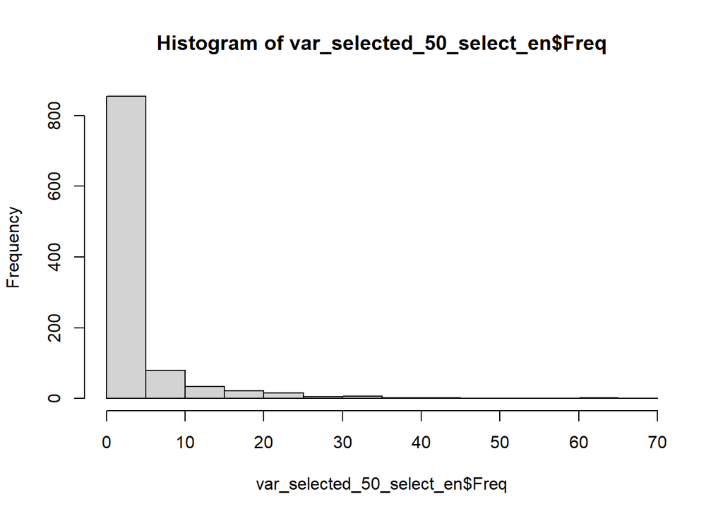

```r
var_selected_50_select_en <- table(unlist(var_selected_alw_select_en))
var_selected_50_select_en <- as.data.frame(var_selected_50_select_en)
var_selected_50_select_en <- var_selected_50_select_en[order(var_selected_50_select_en$Freq, decreasing = T),]
write_xlsx(var_selected_50_select_en,"genes_en_d3.xlsx")
hist(var_selected_50_select_en$Freq)
```

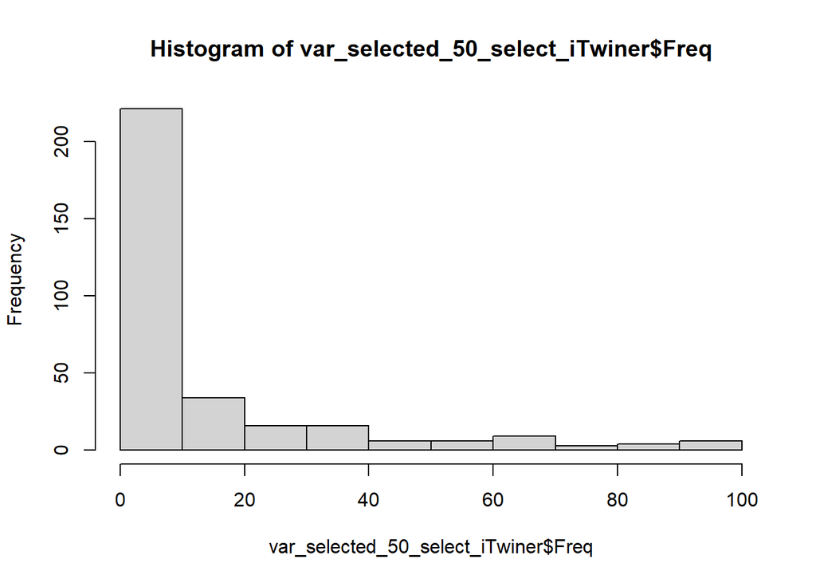

```r
top100_en <- var_selected_50_select_en[1:100,]
top100_en <- top100_en$Var1
top50_en <- top100_en[1:50]


var_selected_50_select_iTwiner <- table(unlist(var_selected_alw_select_iTwiner))
var_selected_50_select_iTwiner <- as.data.frame(var_selected_50_select_iTwiner)
var_selected_50_select_iTwiner <- var_selected_50_select_iTwiner[order(var_selected_50_select_iTwiner$Freq, decreasing = T),]
write_xlsx(var_selected_50_select_iTwiner,"genes_itw_d3.xlsx")
hist(var_selected_50_select_iTwiner$Freq)
```

```r
top100_itw <- var_selected_50_select_iTwiner[1:100,]
top100_itw <- top100_itw$Var1
top50_itw <- top100_itw[1:50]
```

variables in common between EN and iTwiner

```r
common_var_selected_50_en_iTwiner <- var_selected_50_select_iTwiner$Var1[which(var_selected_50_select_iTwiner$Var1 %in% var_selected_50_select_en$Var1)]
length(common_var_selected_50_en_iTwiner)
```

```
## [1] 102
```

```r
common_var_selected_50_en_iTwiner
```

```
##   [1] NME2P2       OPCML-IT2    RAC1P3       HORMAD2      LINC01100
##   [6] NMNAT1P3     MIR602       NDUFA5P10    KDM4F        TRBV11-1
##  [11] APOOP4       IQCF5-AS1    MIR8078      H2BC2P       IGHVIII-2-1
##  [16] TDGF1P7      MIR659       RPL7P12      LINC02059    EEF1B2P6
##  [21] TRAJ49       RPL23AP26    PPP1R14BP4   RNU6-973P    HSPE1P4
##  [26] RNU6-179P    IGHV3-16     MIR8052      DYTN         XRCC6P2
##  [31] MIR6729      COX5AP1      LINC02178    MIR323B      SNORD42A
##  [36] DMD-AS3      RNU6-1105P   RNU6-73P     RNU7-170P    LINC01927
##  [41] RNU6-902P    MIR609       SEPTIN2P1    MIR376B      RNU6-38P
##  [46] RNU7-193P    RPS6P15      VWC2L-IT1    MIR5702      RBMY2XP
##  [51] RNA5SP246    HLA-S        MIR4783      MTATP8P1     RNU6-851P
##  [56] BNIP3P36     SNORD31B     EPPIN-WFDC6  RPS27AP20    TRAV11
##  [61] DNAJA1P6     MIR4667      MIR7156      RNA5SP205    RNU4-75P
##  [66] RNU6-154P    RNU6-521P    RNU6-954P    AGTR2        DUTP5
##  [71] IGHJ1        MIR1243      MIR4493      MIR6782      RNU6-115P
##  [76] RNU7-154P    RPS4XP11     SELENOTP1    SULT6B2P     TDGF1P1
##  [81] CRH          GAPDHP36     IGHV3OR16-13 LINC02726    MIR4317
##  [86] MIR510       MIR587       MIR6083      MIR8069-1    MIR8069-2
##  [91] RNA5SP74     RNU4-11P     RNU4-13P     RNU4-88P     RNU6-1031P
##  [96] RNU6-1050P   RNU6-1293P   RNU6-156P    RNU6-439P    RNU6-603P
## [101] RPL21P108    RPL5P21
## 321 Levels: ABCD1P3 AGTR2 ALOX15P2 AOX3P-AOX2P APOOP4 ARL2BPP2 ... ZDHHC20P2
```

- Variables selected by EN and iTwiner that are DEGs

```r
xdata <- rnaseq1[ order(row.names(rnaseq1)), ]

nomesgenes <- c(as.vector(top50_en),as.vector(top50_itw))
xdata <- xdata[,nomesgenes]
rownames(DATASET1_bal) <- DATASET1_bal$ID
ydata <- as.data.frame(DATASET1_bal[ order(row.names(DATASET1_bal)), ])
rownames(ydata) <- ydata$ID

xdata <- xdata[rownames(xdata) %in%
                 rownames(ydata),]
ydata <- as.data.frame(ydata[rownames(ydata) %in%
                               rownames(xdata),])

# keep features with standard deviation > 0
xdata <- xdata[,sapply(seq(ncol(xdata)), function(ix) {sd(xdata[,ix])}) != 0]
xdata <- t(xdata)

group <- as.factor(ydata$class)
class <- as.data.frame(ydata$class)
```

```r
edgeR.DGElist <- DGEList(counts=xdata, group = group)

# remove genes that do not have one count per million in at least 5 samples
keep <- rowSums(cpm(edgeR.DGElist) >= 1) >= 5
edgeR.DGElist <- edgeR.DGElist[keep ,]

# specify the design setup

design <- model.matrix(~group)

# estimate the dispersion for all read counts across all samples
edgeR.DGElist <- estimateDisp(edgeR.DGElist, design)

# fit the negative binomial model
edger_fit <- glmFit(edgeR.DGElist, design )

# perform the testing for every gene using the neg. binomial model
edger_lrt <- glmLRT(edger_fit)
summary(decideTests(edger_lrt))
```

```
##        groupPm
## Down        16
## NotSig      70
## Up          14
```

```r
# extract results from edger _lrt$ table plus adjusted p- values
DGE.results_edgeR <- topTags(edger_lrt, n = Inf , sort.by = "PValue" , adjust.method = "BH" )

topTags(DGE.results_edgeR) #table with the top10 DEGs
```

```
## Coefficient:  groupPm
##               logFC    logCPM       LR       PValue          FDR
## MIR5002    3.743691 11.668155 28.15728 1.118460e-07 1.118460e-05
## MIR4725    2.745421 11.880671 25.36275 4.750033e-07 2.375017e-05
## RNU6-33P   3.157366 13.900202 20.11418 7.295366e-06 2.431789e-04
## OR4K12P    2.690467  9.653739 18.28260 1.904386e-05 4.410949e-04
## MIR8078    2.510942  9.874437 17.65616 2.646570e-05 4.410949e-04
## MIR8078.1  2.510942  9.874437 17.65616 2.646570e-05 4.410949e-04
## MIR5579    2.488519 10.276224 14.70819 1.254998e-04 1.792855e-03
## RNU6-1263P 2.272510  9.975377 13.60584 2.254833e-04 2.519523e-03
## MIR8052    2.050007  9.583591 13.48010 2.411071e-04 2.519523e-03
## HSPE1P4    2.133826  9.581245 13.39756 2.519523e-04 2.519523e-03
```

```r
genes_deg <- DGE.results_edgeR$table
genes_deg <- genes_deg[which(genes_deg$FDR < 0.05),]
dim(genes_deg)#genes found to be differentially expressed
```

```
## [1] 30  5
```

```r
genes_deg$row <- row.names(genes_deg)
write_xlsx(genes_deg,"genes_deg_enitw_d3.xlsx")

# highly expressed genes
high <- genes_deg[genes_deg$logFC > 0,]
dim(high)
```

```
## [1] 14  6
```

```r
#low expressed genes
low <- genes_deg[genes_deg$logFC < 0,]
dim(low)
```

```
## [1] 16  6
```

#### 3.3.4.3 3) Classification based on genes selected by regularized logistic regression

##### 3.3.4.3.1 EN + Classifiers

```r
xdata <- xdataT


ydata.raw <- as.data.frame(clinic1$class)
ydata.raw$row <- DATASET1$ID

#ydata.raw$class <- c(rep(0,28),rep(1,34))

ydata.raw$`clinic1$class`[ydata.raw$`clinic1$class` == "P"] <- 0
ydata.raw$`clinic1$class`[ydata.raw$`clinic1$class` == "Pm"] <- 1
rownames(ydata.raw) <- DATASET1$ID

xdata <- xdata[rownames(xdata) %in%
                         rownames(ydata.raw),]

ydata.raw <- as.data.frame(ydata.raw[rownames(ydata.raw) %in%
                         rownames(xdata),])

xdata <- xdata[ order(row.names(xdata)), ]

ydata.raw <- ydata.raw[ order(row.names(ydata.raw)), ]



ydata <- as.data.frame(ydata.raw[,1:2])
colnames(ydata) <- c("class","id")

names <- as.vector(top50_en)
xdata_en <- as.data.frame(xdata[,names])

nomesgenes <- colnames(xdata_en)
colnames(xdata_en) <- paste0("Var", 1:50)
xdata_en$type <- as.factor(ydata$class)
ydata$class <- as.numeric(ydata$class)
```

```r
times_boot <- 100

acc_enplus <- matrix(0,5,times_boot)
kappa_enplus<- matrix(0,5,times_boot)
sensitivity_enplus<- matrix(0,5,times_boot)
specificity_enplus <- matrix(0,5,times_boot)
miscl_enplus <- matrix(0,5,times_boot)
fpos_enplus <- matrix(0,5,times_boot)
fneg_enplus <- matrix(0,5,times_boot)

ids_fn_tree1_enplus <- vector("list")
ids_fn_svmL1_enplus <- vector("list")
ids_fn_svmR1_enplus <- vector("list")
ids_fn_logist1_enplus <- vector("list")
ids_fn_rf1_enplus <- vector("list")

ids_fp_tree1_enplus <- vector("list")
ids_fp_svmL1_enplus <- vector("list")
ids_fp_svmR1_enplus <- vector("list")
ids_fp_logist1_enplus <- vector("list")
ids_fp_rf1_enplus <- vector("list")



run = 1000


for (i in 1:times_boot){

  print(i)
  run = run + 11
  set.seed(run)
  print(run)

  ixs <- loose.rock::balanced.train.and.test(which(as.logical(ydata$class)), which(as.logical(!ydata$class)), train.perc = 0.7)

  training <- xdata_en[ixs$train,]
  testing <- xdata_en[ixs$test,]




# Classification - fazer todos com cross validation

## Decision tree
# Fit the model on the training set



  control <- rpart.control(minsplit = 4)

  model2 <- rpart(type~., data = training, method = 'class', control = control)

  # Make predictions on the test data
  pred <- model2 %>% predict(testing, type = "class")

  true <- testing$type

  listafp <- c()
  listafn <- c()

  for (a in which(pred!= true)){

    if (pred[a] == 0) {

      listafp <- c(listafp, a)
    } else {
      listafn <- c(listafn, a)
    }
  }

  fpos_enplus[1,i] <- length(listafp)
  fneg_enplus[1,i] <- length(listafn)
  ids_fn_tree1_enplus[[i]] <- rownames(testing[listafn,])
  ids_fp_tree1_enplus[[i]] <- rownames(testing[listafp,])


  # tree <- rpart(type~., data=training, method = "class")
  #
  # #Testing the model
  # pred <- predict(object=tree,testing,type="class")

  #Calculating accuracy
  t <- table(testing$type,pred)
  result <- confusionMatrix(t)

  acc_enplus[1,i] <- result[["overall"]][["Accuracy"]]
  kappa_enplus[1,i] <- result[["overall"]][["Kappa"]]
  sensitivity_enplus[1,i] <- result[["byClass"]][["Sensitivity"]]
  specificity_enplus[1,i] <- result[["byClass"]][["Specificity"]]
  miscl_enplus[1,i] <- t[1,2]+t[2,1]
  ###



## SVM linear

  svm_Linear <- train(type ~., data = training, method = "svmLinear",
                      trControl=trainControl("cv", number = 10),
                      tuneLength = 10)

  pred <- predict(svm_Linear, newdata = testing)
  #table(testing$type, pred)


  true <- testing$type

  listafp <- c()
  listafn <- c()

  for (a in which(pred!= true)){

    if (pred[a] == 0) {

      listafp <- c(listafp, a)
    } else {
      listafn <- c(listafn, a)
    }
  }

  fpos_enplus[2,i] <- length(listafp)
  fneg_enplus[2,i] <- length(listafn)
  ids_fn_svmL1_enplus[[i]] <- rownames(testing[listafn,])
  ids_fp_svmL1_enplus[[i]] <- rownames(testing[listafp,])

  #Calculating accuracy

  t <- table(testing$type,pred)
  result <- confusionMatrix(t)

  acc_enplus[2,i] <- result[["overall"]][["Accuracy"]]
  kappa_enplus[2,i] <- result[["overall"]][["Kappa"]]
  sensitivity_enplus[2,i] <- result[["byClass"]][["Sensitivity"]]
  specificity_enplus[2,i] <- result[["byClass"]][["Specificity"]]
  miscl_enplus[2,i] <- t[1,2]+t[2,1]

  ###


## SVM radial

  svm_radial <- train(type ~., data = training, method = "svmRadial",
                      trControl=trainControl("cv", number = 10),
                      tuneLength = 10)

  pred <- predict(svm_radial, newdata = testing)
  #table(testing$type, pred)


  true <- testing$type

  listafp <- c()
  listafn <- c()

  for (a in which(pred!= true)){

    if (pred[a] == 0) {

      listafp <- c(listafp, a)
    } else {
      listafn <- c(listafn, a)
    }
  }

  fpos_enplus[3,i] <- length(listafp)
  fneg_enplus[3,i] <- length(listafn)
  ids_fn_svmR1_enplus[[i]] <- rownames(testing[listafn,])
  ids_fp_svmR1_enplus[[i]] <- rownames(testing[listafp,])

  #Calculating accuracy

  t <- table(testing$type,pred)
  result <- confusionMatrix(t)

  acc_enplus[3,i] <- result[["overall"]][["Accuracy"]]
  kappa_enplus[3,i] <- result[["overall"]][["Kappa"]]
  sensitivity_enplus[3,i] <- result[["byClass"]][["Sensitivity"]]
  specificity_enplus[3,i] <- result[["byClass"]][["Specificity"]]
  miscl_enplus[3,i] <- t[1,2]+t[2,1]
  ###



## Logistic Regression


  logist <- train(type ~., data = training, method = "LogitBoost",
                  trControl=trainControl("cv", number = 10),
                  tuneLength = 10)

  pred <- predict(logist,newdata = testing )
  #table(testing$type, pred)



  true <- testing$type

  listafp <- c()
  listafn <- c()

  for (a in which(pred!= true)){

    if (pred[a] == 0) {

      listafp <- c(listafp, a)
    } else {
      listafn <- c(listafn, a)
    }
  }

  fpos_enplus[4,i] <- length(listafp)
  fneg_enplus[4,i] <- length(listafn)
  ids_fn_logist1_enplus[[i]] <- rownames(testing[listafn,])
  ids_fp_logist1_enplus[[i]] <- rownames(testing[listafp,])

  #Calculating accuracy

  t <- table(testing$type,pred)
  result <- confusionMatrix(t)

  acc_enplus[4,i] <- result[["overall"]][["Accuracy"]]
  kappa_enplus[4,i] <- result[["overall"]][["Kappa"]]
  sensitivity_enplus[4,i] <- result[["byClass"]][["Sensitivity"]]
  specificity_enplus[4,i] <- result[["byClass"]][["Specificity"]]
  miscl_enplus[4,i] <- t[1,2]+t[2,1]

  ###



## Random forest

  model.rf <- train(type ~., data = training, method = "rf",
                    trControl=trainControl("cv", number = 10),
                    tuneLength = 10)

  pred <- predict(model.rf,newdata = testing)
  #table(testing$type, pred)


  true <- testing$type

  listafp <- c()
  listafn <- c()

  for (a in which(pred!= true)){

    if (pred[a] == 0) {

      listafp <- c(listafp, a)
    } else {
      listafn <- c(listafn, a)
    }
  }

  fpos_enplus[5,i] <- length(listafp)
  fneg_enplus[5,i] <- length(listafn)
  ids_fn_rf1_enplus[[i]] <- rownames(testing[listafn,])
  ids_fp_rf1_enplus[[i]] <- rownames(testing[listafp,])

  #Calculating accuracy

  t <- table(testing$type,pred)
  result <- confusionMatrix(t)


  acc_enplus[5,i] <- result[["overall"]][["Accuracy"]]
  kappa_enplus[5,i] <- result[["overall"]][["Kappa"]]
  sensitivity_enplus[5,i] <- result[["byClass"]][["Sensitivity"]]
  specificity_enplus[5,i] <- result[["byClass"]][["Specificity"]]
  miscl_enplus[5,i] <- t[1,2]+t[2,1]




  ###




  rm(training,testing)
}
```

###### 3.3.4.3.1.1 Measures of model performance

- Accuracy

```r
# acc
acc_trees <- acc_enplus[1,]
#hist(acc_trees)
mean(acc_trees)
```

```
## [1] 0.6547059
```

```r
median(acc_trees)
```

```
## [1] 0.6470588
```

```r
acc_svm <- acc_enplus[2,]
#hist(acc_svm)
mean(acc_svm)
```

```
## [1] 0.7264706
```

```r
median(acc_svm)
```

```
## [1] 0.7058824
```

```r
acc_svmR <- acc_enplus[3,]
#hist(acc_svmR)
mean(acc_svmR)
```

```
## [1] 0.7370588
```

```r
median(acc_svmR)
```

```
## [1] 0.7647059
```

```r
acc_logs <- acc_enplus[4,]
#hist(acc_logs)
mean(acc_logs)
```

```
## [1] 0.7558824
```

```r
median(acc_logs)
```

```
## [1] 0.7647059
```

```r
acc_rf <- acc_enplus[5,]
#hist(acc_rf)
mean(acc_rf)
```

```
## [1] 0.7841176
```

```r
median(acc_rf)
```

```
## [1] 0.7647059
```

- Misclassification

```r
# miscl
miscl_trees <- miscl_enplus[1,]
#hist(miscl_trees)
mean(miscl_trees)
```

```
## [1] 5.87
```

```r
median(miscl_trees)
```

```
## [1] 6
```

```r
miscl_svm <- miscl_enplus[2,]
#hist(miscl_svm)
mean(miscl_svm)
```

```
## [1] 4.65
```

```r
median(miscl_svm)
```

```
## [1] 5
```

```r
miscl_svmR <- miscl_enplus[3,]
#hist(miscl_svmR)
mean(miscl_svmR)
```

```
## [1] 4.47
```

```r
median(miscl_svmR)
```

```
## [1] 4
```

```r
miscl_logs <- miscl_enplus[4,]
#hist(miscl_logs)
mean(miscl_logs)
```

```
## [1] 4.15
```

```r
median(miscl_logs)
```

```
## [1] 4
```

```r
miscl_rf <- miscl_enplus[5,]
#hist(miscl_rf)
mean(miscl_rf)
```

```
## [1] 3.67
```

```r
median(miscl_rf)
```

```
## [1] 4
```

- Sensitivity

```r
# sensitivity
sensitivity_trees <- sensitivity_enplus[1,]
sensitivity_trees <- na.omit(sensitivity_trees)
#hist(sensitivity_trees)
mean(sensitivity_trees)
```

```
## [1] 0.6497067
```

```r
median(sensitivity_trees)
```

```
## [1] 0.6363636
```

```r
sensitivity_svm <- sensitivity_enplus[2,]
#hist(sensitivity_svm)
mean(sensitivity_svm)
```

```
## [1] 0.7453315
```

```r
median(sensitivity_svm)
```

```
## [1] 0.75
```

```r
sensitivity_svmR <- sensitivity_enplus[3,]
sensitivity_svmR <- na.omit(sensitivity_svmR)
#hist(sensitivity_svmR)
mean(sensitivity_svmR)
```

```
## [1] 0.7520307
```

```r
median(sensitivity_svmR)
```

```
## [1] 0.75
```

```r
sensitivity_logs <- sensitivity_enplus[4,]
#hist(sensitivity_logs)
mean(sensitivity_logs)
```

```
## [1] 0.7717229
```

```r
median(sensitivity_logs)
```

```
## [1] 0.75
```

```r
sensitivity_rf <- sensitivity_enplus[5,]
#hist(sensitivity_rf)
mean(sensitivity_rf)
```

```
## [1] 0.9026934
```

```r
median(sensitivity_rf)
```

```
## [1] 1
```

- Specificity

```r
# specificity
specificity_trees <- specificity_enplus[1,]
specificity_trees <- na.omit(specificity_trees)
#hist(specificity_trees)
mean(specificity_trees)
```

```
## [1] 0.67966
```

```r
median(specificity_trees)
```

```
## [1] 0.6666667
```

```r
specificity_svm <- specificity_enplus[2,]
#hist(specificity_svm)
mean(specificity_svm)
```

```
## [1] 0.7390716
```

```r
median(specificity_svm)
```

```
## [1] 0.7272727
```

```r
specificity_svmR <- specificity_enplus[3,]
#hist(specificity_svmR)
mean(specificity_svmR)
```

```
## [1] 0.7594688
```

```r
median(specificity_svmR)
```

```
## [1] 0.7386364
```

```r
specificity_logs <- specificity_enplus[4,]
#hist(specificity_logs)
mean(specificity_logs)
```

```
## [1] 0.7688017
```

```r
median(specificity_logs)
```

```
## [1] 0.75
```

```r
specificity_rf <- specificity_enplus[5,]
#hist(specificity_rf)
mean(specificity_rf)
```

```
## [1] 0.7439313
```

```r
median(specificity_rf)
```

```
## [1] 0.7272727
```

- False Neg

```r
# fneg
fneg_trees <- fneg_enplus[1,]
#hist(fneg_trees)
mean(fneg_trees)
```

```
## [1] 3
```

```r
median(fneg_trees)
```

```
## [1] 3
```

```r
fneg_svmL <- fneg_enplus[2,]
#hist(fneg_svmL)
mean(fneg_svmL)
```

```
## [1] 2.68
```

```r
median(fneg_svmL)
```

```
## [1] 3
```

```r
fneg_svmR <- fneg_enplus[3,]
#hist(fneg_svmR)
mean(fneg_svmR)
```

```
## [1] 2.38
```

```r
median(fneg_svmR)
```

```
## [1] 2
```

```r
fneg_logs <- fneg_enplus[4,]
#hist(fneg_logs)
mean(fneg_logs)
```

```
## [1] 2.32
```

```r
median(fneg_logs)
```

```
## [1] 2
```

```r
fneg_rf <- fneg_enplus[5,]
#hist(fneg_rf)
mean(fneg_rf)
```

```
## [1] 3.05
```

```r
median(fneg_rf)
```

```
## [1] 3
```

##### 3.3.4.3.2 iTwiner + classifiers

```r
xdata <- xdataT


ydata.raw <- as.data.frame(clinic1$class)
ydata.raw$row <- DATASET1$ID

#ydata.raw$class <- c(rep(0,28),rep(1,34))

ydata.raw$`clinic1$class`[ydata.raw$`clinic1$class` == "P"] <- 0
ydata.raw$`clinic1$class`[ydata.raw$`clinic1$class` == "Pm"] <- 1
rownames(ydata.raw) <- DATASET1$ID

xdata <- xdata[rownames(xdata) %in%
                         rownames(ydata.raw),]

ydata.raw <- as.data.frame(ydata.raw[rownames(ydata.raw) %in%
                         rownames(xdata),])

xdata <- xdata[ order(row.names(xdata)), ]

ydata.raw <- ydata.raw[ order(row.names(ydata.raw)), ]



ydata <- as.data.frame(ydata.raw[,1:2])
colnames(ydata) <- c("class","id")

names <- as.vector(top50_itw)
xdata_iTwiner <- as.data.frame(xdata[,names])

nomesgenes <- colnames(xdata_iTwiner)
colnames(xdata_iTwiner) <- paste0("Var", 1:50)
xdata_iTwiner$type <- as.factor(ydata$class)
ydata$class <- as.numeric(ydata$class)
```

```r
# Performing 100 train and test
times_boot <- 100

acc_tcoxplus <- matrix(0,5,times_boot)
kappa_tcoxplus<- matrix(0,5,times_boot)
sensitivity_tcoxplus<- matrix(0,5,times_boot)
specificity_tcoxplus <- matrix(0,5,times_boot)
miscl_tcoxplus <- matrix(0,5,times_boot)
fpos_tcoxplus <- matrix(0,5,times_boot)
fneg_tcoxplus <- matrix(0,5,times_boot)

ids_fn_tree1_tcoxplus <- vector("list")
ids_fn_svmL1_tcoxplus <- vector("list")
ids_fn_svmR1_tcoxplus <- vector("list")
ids_fn_logist1_tcoxplus <- vector("list")
ids_fn_rf1_tcoxplus <- vector("list")

ids_fp_tree1_tcoxplus <- vector("list")
ids_fp_svmL1_tcoxplus <- vector("list")
ids_fp_svmR1_tcoxplus <- vector("list")
ids_fp_logist1_tcoxplus <- vector("list")
ids_fp_rf1_tcoxplus <- vector("list")


run = 1000


for (i in 1:times_boot){

  print(i)
  run = run + 11
  set.seed(run)
  print(run)

  ixs <- loose.rock::balanced.train.and.test(which(as.logical(ydata$class)), which(as.logical(!ydata$class)), train.perc = 0.7)

  training <- xdata_iTwiner[ixs$train,]
  testing <- xdata_iTwiner[ixs$test,]


# Classification - fazer todos com cross validation

## Decision tree
# Fit the model on the training set
control <- rpart.control(minsplit = 4)

  model2 <- rpart(type~., data = training, method = 'class', control = control)

  # Make predictions on the test data
  pred <- model2 %>% predict(testing, type = "class")

  true <- testing$type

  listafp <- c()
  listafn <- c()

  for (a in which(pred!= true)){

    if (pred[a] == 0) {

      listafp <- c(listafp, a)
    } else {
      listafn <- c(listafn, a)
    }
  }

  fpos_tcoxplus[1,i] <- length(listafp)
  fneg_tcoxplus[1,i] <- length(listafn)
  ids_fn_tree1_tcoxplus[[i]] <- rownames(testing[listafn,])
  ids_fp_tree1_tcoxplus[[i]] <- rownames(testing[listafp,])


  # tree <- rpart(type~., data=training, method = "class")
  #
  # #Testing the model
  # pred <- predict(object=tree,testing,type="class")

  #Calculating accuracy
  t <- table(testing$type,pred)
  result <- confusionMatrix(t)

  acc_tcoxplus[1,i] <- result[["overall"]][["Accuracy"]]
  kappa_tcoxplus[1,i] <- result[["overall"]][["Kappa"]]
  sensitivity_tcoxplus[1,i] <- result[["byClass"]][["Sensitivity"]]
  specificity_tcoxplus[1,i] <- result[["byClass"]][["Specificity"]]
  miscl_tcoxplus[1,i] <- t[1,2]+t[2,1]
  ###



## SVM linear

  svm_Linear <- train(type ~., data = training, method = "svmLinear",
                      trControl=trainControl("cv", number = 10),
                      tuneLength = 10)

  pred <- predict(svm_Linear, newdata = testing)
  #table(testing$type, pred)


  true <- testing$type

  listafp <- c()
  listafn <- c()

  for (a in which(pred!= true)){

    if (pred[a] == 0) {

      listafp <- c(listafp, a)
    } else {
      listafn <- c(listafn, a)
    }
  }

  fpos_tcoxplus[2,i] <- length(listafp)
  fneg_tcoxplus[2,i] <- length(listafn)
  ids_fn_svmL1_tcoxplus[[i]] <- rownames(testing[listafn,])
  ids_fp_svmL1_tcoxplus[[i]] <- rownames(testing[listafp,])

  #Calculating accuracy

  t <- table(testing$type,pred)
  result <- confusionMatrix(t)

  acc_tcoxplus[2,i] <- result[["overall"]][["Accuracy"]]
  kappa_tcoxplus[2,i] <- result[["overall"]][["Kappa"]]
  sensitivity_tcoxplus[2,i] <- result[["byClass"]][["Sensitivity"]]
  specificity_tcoxplus[2,i] <- result[["byClass"]][["Specificity"]]
  miscl_tcoxplus[2,i] <- t[1,2]+t[2,1]

  ###


## SVM radial

  svm_radial <- train(type ~., data = training, method = "svmRadial",
                      trControl=trainControl("cv", number = 10),
                      tuneLength = 10)

  pred <- predict(svm_radial, newdata = testing)
  #table(testing$type, pred)


  true <- testing$type

  listafp <- c()
  listafn <- c()

  for (a in which(pred!= true)){

    if (pred[a] == 0) {

      listafp <- c(listafp, a)
    }  else {
      listafn <- c(listafn, a)
    }
  }

  fpos_tcoxplus[3,i] <- length(listafp)
  fneg_tcoxplus[3,i] <- length(listafn)
  ids_fn_svmR1_tcoxplus[[i]] <- rownames(testing[listafn,])
  ids_fp_svmR1_tcoxplus[[i]] <- rownames(testing[listafp,])

  #Calculating accuracy

  t <- table(testing$type,pred)
  result <- confusionMatrix(t)

  acc_tcoxplus[3,i] <- result[["overall"]][["Accuracy"]]
  kappa_tcoxplus[3,i] <- result[["overall"]][["Kappa"]]
  sensitivity_tcoxplus[3,i] <- result[["byClass"]][["Sensitivity"]]
  specificity_tcoxplus[3,i] <- result[["byClass"]][["Specificity"]]
  miscl_tcoxplus[3,i] <- t[1,2]+t[2,1]
  ###



## Logistic Regression


  logist <- train(type ~., data = training, method = "LogitBoost",
                  trControl=trainControl("cv", number = 10),
                  tuneLength = 10)

  pred <- predict(logist,newdata = testing )
  #table(testing$type, pred)



  true <- testing$type

  listafp <- c()
  listafn <- c()

  for (a in which(pred!= true)){

    if (pred[a] == 0) {

      listafp <- c(listafp, a)
    } else {
      listafn <- c(listafn, a)
    }
  }

  fpos_tcoxplus[4,i] <- length(listafp)
  fneg_tcoxplus[4,i] <- length(listafn)
  ids_fn_logist1_tcoxplus[[i]] <- rownames(testing[listafn,])
  ids_fp_logist1_tcoxplus[[i]] <- rownames(testing[listafp,])

  #Calculating accuracy

  t <- table(testing$type,pred)
  result <- confusionMatrix(t)

  acc_tcoxplus[4,i] <- result[["overall"]][["Accuracy"]]
  kappa_tcoxplus[4,i] <- result[["overall"]][["Kappa"]]
  sensitivity_tcoxplus[4,i] <- result[["byClass"]][["Sensitivity"]]
  specificity_tcoxplus[4,i] <- result[["byClass"]][["Specificity"]]
  miscl_tcoxplus[4,i] <- t[1,2]+t[2,1]

  ###



## Random forest

  model.rf <- train(type ~., data = training, method = "rf",
                    trControl=trainControl("cv", number = 10),
                    tuneLength = 10)

  pred <- predict(model.rf,newdata = testing)
  #table(testing$type, pred)


  true <- testing$type

  listafp <- c()
  listafn <- c()

  for (a in which(pred!= true)){

    if (pred[a] == 0) {

      listafp <- c(listafp, a)
    } else {
      listafn <- c(listafn, a)
    }
  }

  fpos_tcoxplus[5,i] <- length(listafp)
  fneg_tcoxplus[5,i] <- length(listafn)
  ids_fn_rf1_tcoxplus[[i]] <- rownames(testing[listafn,])
  ids_fp_rf1_tcoxplus[[i]] <- rownames(testing[listafp,])

  #Calculating accuracy

  t <- table(testing$type,pred)
  result <- confusionMatrix(t)


  acc_tcoxplus[5,i] <- result[["overall"]][["Accuracy"]]
  kappa_tcoxplus[5,i] <- result[["overall"]][["Kappa"]]
  sensitivity_tcoxplus[5,i] <- result[["byClass"]][["Sensitivity"]]
  specificity_tcoxplus[5,i] <- result[["byClass"]][["Specificity"]]
  miscl_tcoxplus[5,i] <- t[1,2]+t[2,1]




  ###




  rm(training,testing)
}
```

[output not shown]

[output cut: 48 more lines]

[output not shown]

###### 3.3.4.3.2.1 Measures of model performance

- Accuracy

```r
# acc
acc_trees <- acc_tcoxplus[1,]
#hist(acc_trees)
mean(acc_trees)
```

```
## [1] 0.6817647
```

```r
median(acc_trees)
```

```
## [1] 0.6470588
```

```r
acc_svm <- acc_tcoxplus[2,]
#hist(acc_svm)
mean(acc_svm)
```

```
## [1] 0.7135294
```

```r
median(acc_svm)
```

```
## [1] 0.7058824
```

```r
acc_svmR <- acc_tcoxplus[3,]
#hist(acc_svmR)
mean(acc_svmR)
```

```
## [1] 0.6247059
```

```r
median(acc_svmR)
```

```
## [1] 0.5882353
```

```r
acc_logs <- acc_tcoxplus[4,]
#hist(acc_logs)
mean(acc_logs)
```

```
## [1] 0.63
```

```r
median(acc_logs)
```

```
## [1] 0.6470588
```

```r
acc_rf <- acc_tcoxplus[5,]
#hist(acc_rf)
mean(acc_rf)
```

```
## [1] 0.7505882
```

```r
median(acc_rf)
```

```
## [1] 0.7647059
```

- Misclassification

```r
# miscl
miscl_trees <- miscl_tcoxplus[1,]
#hist(miscl_trees)
mean(miscl_trees)
```

```
## [1] 5.41
```

```r
median(miscl_trees)
```

```
## [1] 6
```

```r
miscl_svm <- miscl_tcoxplus[2,]
#hist(miscl_svm)
mean(miscl_svm)
```

```
## [1] 4.87
```

```r
median(miscl_svm)
```

```
## [1] 5
```

```r
miscl_svmR <- miscl_tcoxplus[3,]
#hist(miscl_svmR)
mean(miscl_svmR)
```

```
## [1] 6.38
```

```r
median(miscl_svmR)
```

```
## [1] 7
```

```r
miscl_logs <- miscl_tcoxplus[4,]
#hist(miscl_logs)
mean(miscl_logs)
```

```
## [1] 6.29
```

```r
median(miscl_logs)
```

```
## [1] 6
```

```r
miscl_rf <- miscl_tcoxplus[5,]
#hist(miscl_rf)
mean(miscl_rf)
```

```
## [1] 4.24
```

```r
median(miscl_rf)
```

```
## [1] 4
```

- Sensitivity

```r
# sensitivity
sensitivity_trees <- sensitivity_tcoxplus[1,]
sensitivity_trees <- na.omit(sensitivity_trees)
#hist(sensitivity_trees)
mean(sensitivity_trees)
```

```
## [1] 0.6934563
```

```r
median(sensitivity_trees)
```

```
## [1] 0.6666667
```

```r
sensitivity_svm <- sensitivity_tcoxplus[2,]
#hist(sensitivity_svm)
mean(sensitivity_svm)
```

```
## [1] 0.916
```

```r
median(sensitivity_svm)
```

```
## [1] 1
```

```r
sensitivity_svmR <- sensitivity_tcoxplus[3,]
sensitivity_svmR <- na.omit(sensitivity_svmR)
#hist(sensitivity_svmR)
mean(sensitivity_svmR)
```

```
## [1] 0.6922206
```

```r
median(sensitivity_svmR)
```

```
## [1] 0.6666667
```

```r
sensitivity_logs <- sensitivity_tcoxplus[4,]
#hist(sensitivity_logs)
mean(sensitivity_logs)
```

```
## [1] 0.6243564
```

```r
median(sensitivity_logs)
```

```
## [1] 0.6
```

```r
sensitivity_rf <- sensitivity_tcoxplus[5,]
#hist(sensitivity_rf)
mean(sensitivity_rf)
```

```
## [1] 0.942399
```

```r
median(sensitivity_rf)
```

```
## [1] 1
```

- Specificity

```r
# specificity
specificity_trees <- specificity_tcoxplus[1,]
specificity_trees <- na.omit(specificity_trees)
#hist(specificity_trees)
mean(specificity_trees)
```

```
## [1] 0.6945902
```

```r
median(specificity_trees)
```

```
## [1] 0.7
```

```r
specificity_svm <- specificity_tcoxplus[2,]
#hist(specificity_svm)
mean(specificity_svm)
```

```
## [1] 0.6627875
```

```r
median(specificity_svm)
```

```
## [1] 0.6428571
```

```r
specificity_svmR <- specificity_tcoxplus[3,]
#hist(specificity_svmR)
mean(specificity_svmR)
```

```
## [1] 0.6195017
```

```r
median(specificity_svmR)
```

```
## [1] 0.6363636
```

```r
specificity_logs <- specificity_tcoxplus[4,]
#hist(specificity_logs)
mean(specificity_logs)
```

```
## [1] 0.6437668
```

```r
median(specificity_logs)
```

```
## [1] 0.6306818
```

```r
specificity_rf <- specificity_tcoxplus[5,]
#hist(specificity_rf)
mean(specificity_rf)
```

```
## [1] 0.6970615
```

```r
median(specificity_rf)
```

```
## [1] 0.6923077
```

- False Neg

```r
# fneg
fneg_trees <- fneg_tcoxplus[1,]
#hist(fneg_trees)
mean(fneg_trees)
```

```
## [1] 3.09
```

```r
median(fneg_trees)
```

```
## [1] 3
```

```r
fneg_svmL <- fneg_tcoxplus[2,]
#hist(fneg_svmL)
mean(fneg_svmL)
```

```
## [1] 4.47
```

```r
median(fneg_svmL)
```

```
## [1] 4
```

```r
fneg_svmR <- fneg_tcoxplus[3,]
#hist(fneg_svmR)
mean(fneg_svmR)
```

```
## [1] 4.58
```

```r
median(fneg_svmR)
```

```
## [1] 4
```

```r
fneg_logs <- fneg_tcoxplus[4,]
#hist(fneg_logs)
mean(fneg_logs)
```

```
## [1] 3.65
```

```r
median(fneg_logs)
```

```
## [1] 4
```

```r
fneg_rf <- fneg_tcoxplus[5,]
#hist(fneg_rf)
mean(fneg_rf)
```

```
## [1] 3.84
```

```r
median(fneg_rf)
```

```
## [1] 4
```

### 3.3.5 Data final

```r
dt3 <- acc[1,]
dt_en3 <- acc_enplus[1,]
dt_iTwiner3 <- acc_tcoxplus[1,]

acc_dt3 <- as.data.frame(c(dt3,dt_en3, dt_iTwiner3
                           #,dt_hub
))
colnames(acc_dt3) <- "acc"

acc_dt3$group <- "DT"
acc_dt3$group[101:200] <- "EN + DT"
acc_dt3$group[201:300] <- "iTwiner + DT"
acc_dt3<- acc_dt3 %>% mutate_if(is.character,factor)
# acc_dt$group <- ordered(acc_dt$group, levels = c("DT", "EN + DT","iTwiner + DT", "HUB + DT"))
acc_dt3$group <- ordered(acc_dt3$group, levels = c("DT", "EN + DT","iTwiner + DT"))

acc_dt3$dataset <- "DATASET3"



svmL3 <- acc[2,]
svmL_en3 <- acc_enplus[2,]
svmL_iTwiner3 <- acc_tcoxplus[2,]

acc_svmL3 <- as.data.frame(c(svmL3,svmL_en3, svmL_iTwiner3
                             #,svmL_hub
))
colnames(acc_svmL3) <- "acc"
acc_svmL3$group <- "svmL"
acc_svmL3$group[101:200] <- "EN + svmL"
acc_svmL3$group[201:300] <- "iTwiner + svmL"
acc_svmL3<- acc_svmL3 %>% mutate_if(is.character,factor)
acc_svmL3$group <- ordered(acc_svmL3$group, levels = c("svmL", "EN + svmL","iTwiner + svmL"))

acc_svmL3$dataset <- "DATASET3"




svmR3 <- acc[3,]
svmR_en3 <- acc_enplus[3,]
svmR_iTwiner3 <- acc_tcoxplus[3,]

acc_svmR3 <- as.data.frame(c(svmR3,svmR_en3, svmR_iTwiner3
                             #,svmR_hub
))
colnames(acc_svmR3) <- "acc"
acc_svmR3$group <- "svmR"
acc_svmR3$group[101:200] <- "EN + svmR"
acc_svmR3$group[201:300] <- "iTwiner + svmR"
acc_svmR3<- acc_svmR3 %>% mutate_if(is.character,factor)
acc_svmR3$group <- ordered(acc_svmR3$group, levels = c("svmR", "EN + svmR","iTwiner + svmR"))

acc_svmR3$dataset <- "DATASET3"






logist3 <- acc[4,]
logist_en3 <- acc_enplus[4,]
logist_iTwiner3 <- acc_tcoxplus[4,]

acc_logist3 <- as.data.frame(c(logist3,logist_en3, logist_iTwiner3
                               #,logist_hub
))
colnames(acc_logist3) <- "acc"
acc_logist3$group <- "logist"
acc_logist3$group[101:200] <- "EN + logist"
acc_logist3$group[201:300] <- "iTwiner + logist"
acc_logist3<- acc_logist3 %>% mutate_if(is.character,factor)
acc_logist3$group <- ordered(acc_logist3$group, levels = c("logist", "EN + logist","iTwiner + logist"))

acc_logist3$dataset <- "DATASET3"






rf3 <- acc[5,]
rf_en3 <- acc_enplus[5,]
rf_iTwiner3 <- acc_tcoxplus[5,]

acc_rf3 <- as.data.frame(c(rf3,rf_en3, rf_iTwiner3
                           #,rf_hub
))
colnames(acc_rf3) <- "acc"
acc_rf3$group <- "rf"
acc_rf3$group[101:200] <- "EN + rf"
acc_rf3$group[201:300] <- "iTwiner + rf"
acc_rf3<- acc_rf3 %>% mutate_if(is.character,factor)
acc_rf3$group <- ordered(acc_rf3$group, levels = c("rf", "EN + rf","iTwiner + rf"))

acc_rf3$dataset <- "DATASET3"
```

```r
# save results

save.image("~/results3_2010.RData")
```

# 4 final results

- Plots comparing data partitions after running chunk bellow (line 208) for the three distinct datasets

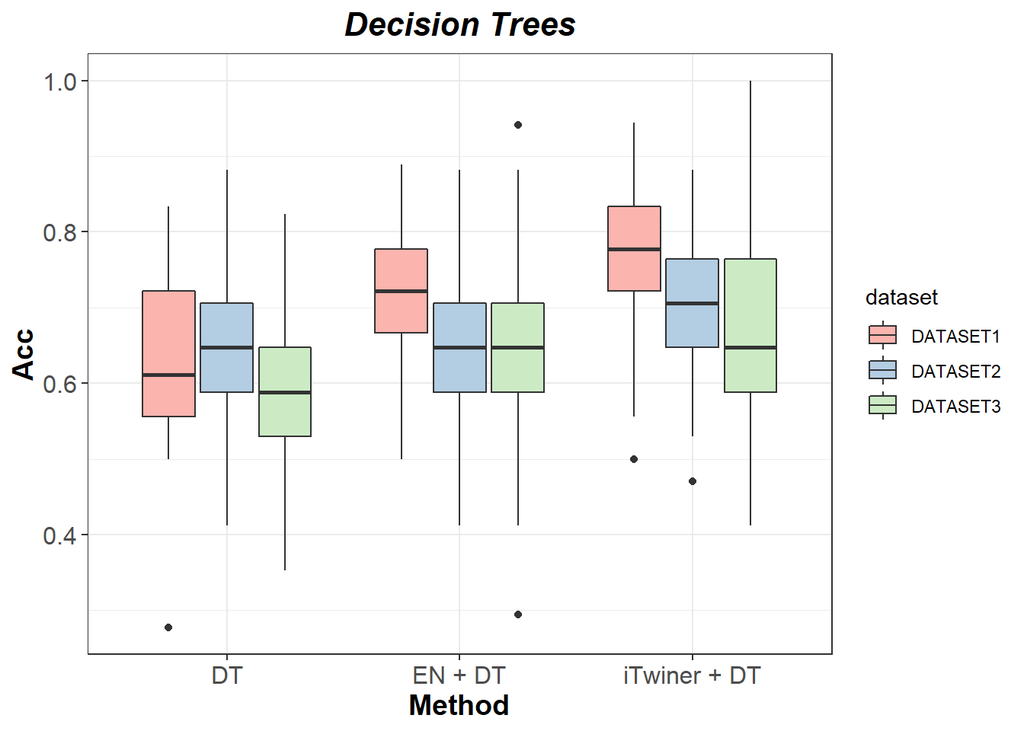

```r
# Libraries
library(ggplot2)
library(dplyr)
library(forcats)
library(hrbrthemes)
library(viridis)
data_dt <- rbind(acc_dt1,acc_dt2,acc_dt3)


p <- ggplot(data_dt, aes(x = group , y = acc, fill = dataset )) + geom_boxplot()

p <- p + theme_bw()
p + scale_fill_brewer(palette="Pastel1") + labs(title="Decision Trees",x="Method", y = "Acc") + theme(plot.title = element_text(size = 16, face = "bold.italic", hjust = 0.5),  axis.text = element_text(size = 12), axis.title=element_text(size=14,face="bold") )
```

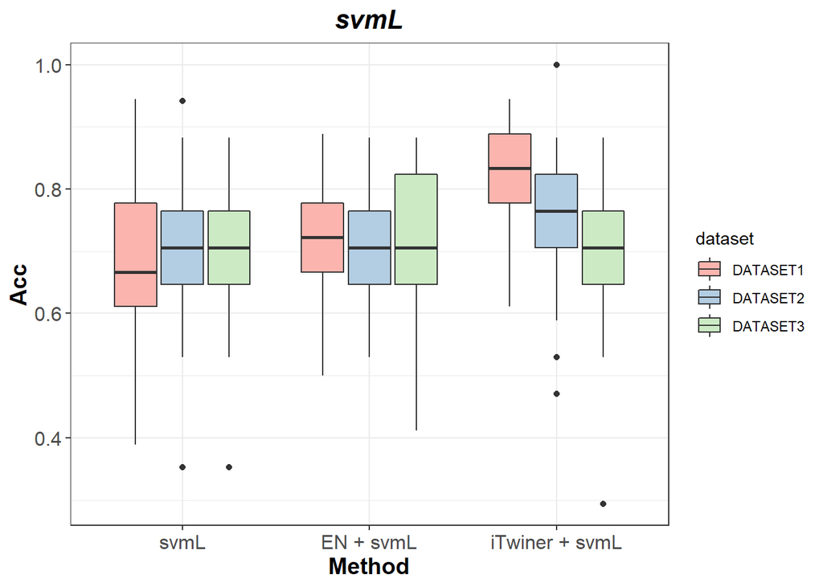

```r
data_svmL <- rbind(acc_svmL1,acc_svmL2,acc_svmL3)


p <- ggplot(data_svmL, aes(x = group , y = acc, fill = dataset )) + geom_boxplot()

p <- p + theme_bw()
p + scale_fill_brewer(palette="Pastel1") + labs(title="svmL",x="Method", y = "Acc") + theme(plot.title = element_text(size = 16, face = "bold.italic", hjust = 0.5),  axis.text = element_text(size = 12), axis.title=element_text(size=14,face="bold") )
```

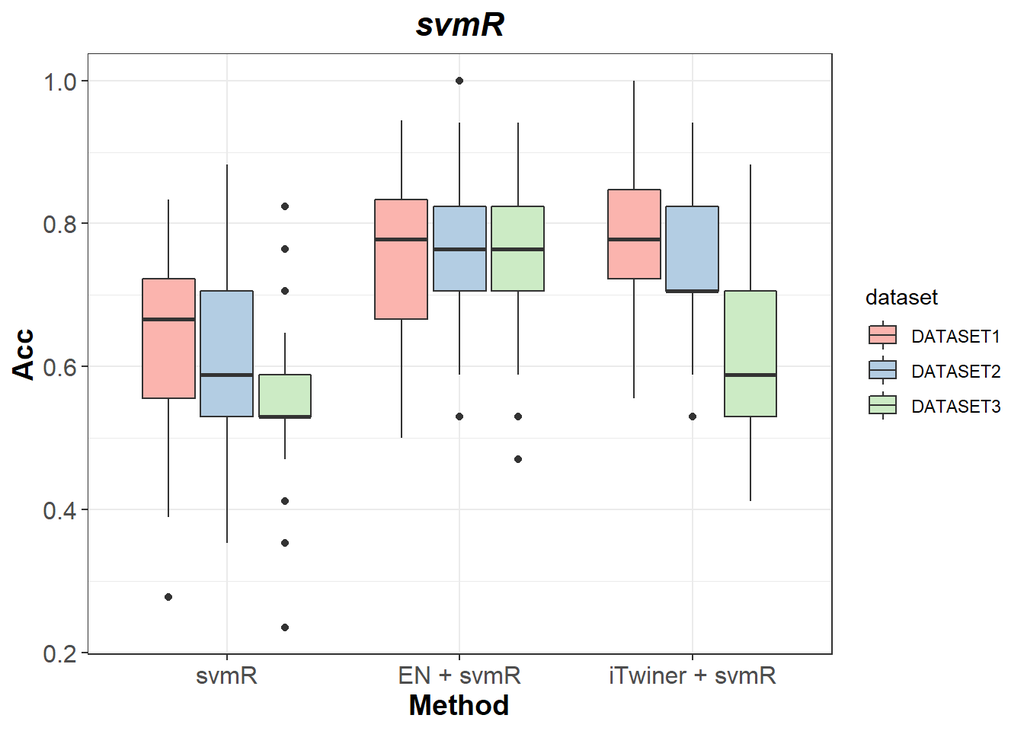

```r
data_svmR <- rbind(acc_svmR1,acc_svmR2,acc_svmR3)


p <- ggplot(data_svmR, aes(x = group , y = acc, fill = dataset )) + geom_boxplot()

p <- p + theme_bw()
p + scale_fill_brewer(palette="Pastel1") + labs(title="svmR",x="Method", y = "Acc") + theme(plot.title = element_text(size = 16, face = "bold.italic", hjust = 0.5),  axis.text = element_text(size = 12), axis.title=element_text(size=14,face="bold") )
```

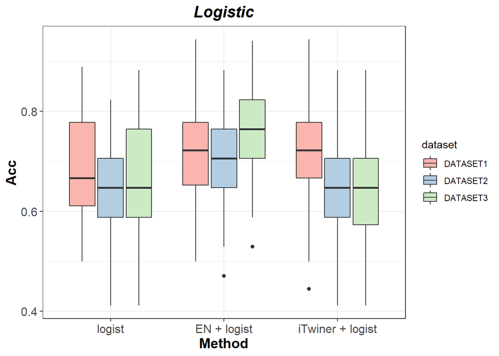

```r
data_logis <- rbind(acc_logist1,acc_logist2,acc_logist3)


p <- ggplot(data_logis, aes(x = group , y = acc, fill = dataset )) + geom_boxplot()

p <- p + theme_bw()
p + scale_fill_brewer(palette="Pastel1") + labs(title="Logistic",x="Method", y = "Acc") + theme(plot.title = element_text(size = 16, face = "bold.italic", hjust = 0.5),  axis.text = element_text(size = 12), axis.title=element_text(size=14,face="bold") )
```

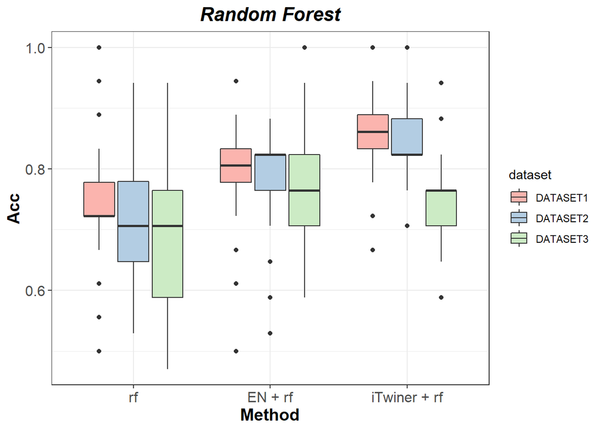

```r
data_rf <- rbind(acc_rf1,acc_rf2,acc_rf3)


p <- ggplot(data_rf, aes(x = group , y = acc, fill = dataset )) + geom_boxplot()

p <- p + theme_bw()
p + scale_fill_brewer(palette="Pastel1") + labs(title="Random Forest",x="Method", y = "Acc") + theme(plot.title = element_text(size = 16, face = "bold.italic", hjust = 0.5),  axis.text = element_text(size = 12), axis.title=element_text(size=14,face="bold") )
```